# Week 11 Weekend Homework | Logistic Regression

```
here() starts at C:/Users/colin/Documents/CodeClan/codeclan_homework_ColinS/week_11/weekend_homework

For binary classification, the first factor level is assumed to be the event.
Use the argument `event_level = "second"` to alter this as needed.
```

```
[1] "C:/Users/colin/Documents/CodeClan/codeclan_homework_ColinS/week_11/weekend_homework"
```

## Read the Data

```r
juice <- read_csv(here("data/orange_juice.csv")) %>% clean_names()
# head(juice)
# str(juice)
# dim(juice)
```

Set up the test-train split. There are 1070 observations, so an 80/20 split would provide around 800 rows for training and 200 for testing;

```r
test_index <- sample(1:nrow(juice), size = nrow(juice)*0.2) # random 20% to be used for test

juice_test  <- slice(juice, test_index)   # create test set
juice_train <- slice(juice, -test_index)  # create training set
```

## Tidy the Data for Logistic Regression

It looks like there are several connections between various columns;

- `store7`, `store_id` and `store` look like they could be connected
- Several price columns look like they are linked

```r
alias(lm(store ~ ., data = juice_train))
```

```
Model :
store ~ purchase + weekof_purchase + store_id + price_ch + price_mm +
    disc_ch + disc_mm + special_ch + special_mm + loyal_ch +
    sale_price_mm + sale_price_ch + price_diff + store7 + pct_disc_mm +
    pct_disc_ch + list_price_diff

Complete :
                (Intercept) purchaseMM weekof_purchase store_id price_ch
sale_price_mm    0           0          0               0        0
sale_price_ch    0           0          0               0        1
price_diff       0           0          0               0       -1
list_price_diff  0           0          0               0       -1
                price_mm disc_ch disc_mm special_ch special_mm loyal_ch
sale_price_mm    1        0      -1       0          0          0
sale_price_ch    0       -1       0       0          0          0
price_diff       1        1      -1       0          0          0
list_price_diff  1        0       0       0          0          0
                store7Yes pct_disc_mm pct_disc_ch
sale_price_mm    0         0           0
sale_price_ch    0         0           0
price_diff       0         0           0
list_price_diff  0         0           0
```

The `alias` function shows the following;

- sale_price_mm = price_mm - disc_mm
- sale_price_ch = price_ch - disc_ch
- price_diff = price_mm - price_ch + disc_ch - disc_mm
- list_price_diff = price_mm - price_ch

In addition, it looks like `store`, `store7` and `store_id` are also connected;

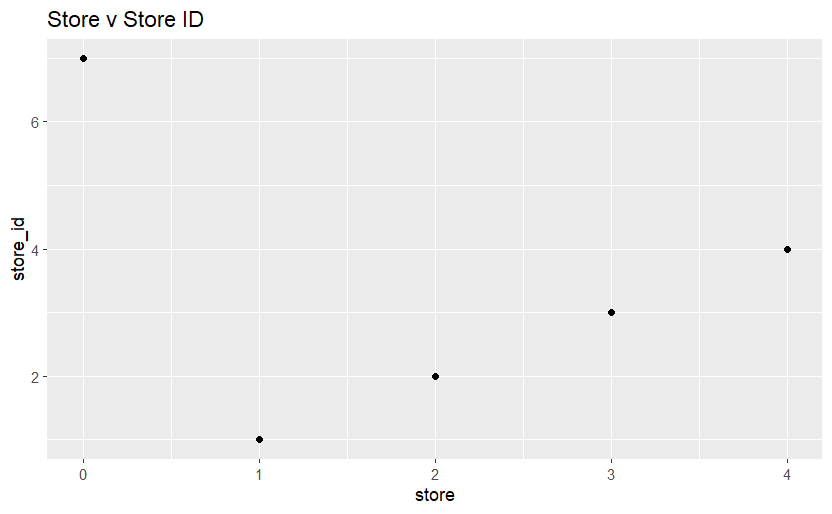

```r
juice_train %>%
  ggplot() +
  aes(x = store, y = store_id) +
  geom_point() +
  labs(title = "Store v Store ID")
```

This plot clearly shows that `store` and `store_id` are connected;

- Store 0 = Store ID 7
- Store 1 = Store ID 1
- Store 2 = Store ID 2
- Store 3 = Store ID 3
- Store 4 = Store ID 4

So in summary, the following columns can safely be removed;

sale_price_mm, sale_price_ch, price_diff, list_price_diff, store_id, store7

### Tidy Up

The `purchase` column may be difficult to run in logistic regression and will be set as a logical answer to the question “did the customer buy Minute Maid?”

```r
juice_train_trim <- juice_train %>%
  mutate(purchase = if_else(purchase == "MM", as.logical(TRUE), as.logical(FALSE))) %>%
  select(-c(sale_price_mm,
            sale_price_ch,
            price_diff,
            list_price_diff,
            store_id,
            store7))
```

[output not shown]

[output cut: 100 more lines]

[output not shown]

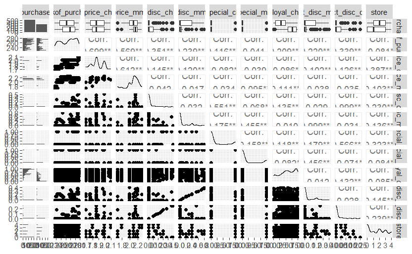

```r
ggpairs(juice_train_trim)
```

```r
NA
```

Looking at the ggpairs, it seems like the customer brand loyalty score for Citrus Hill is by far the biggest factor in deciding if any customer bought Minute Maid;

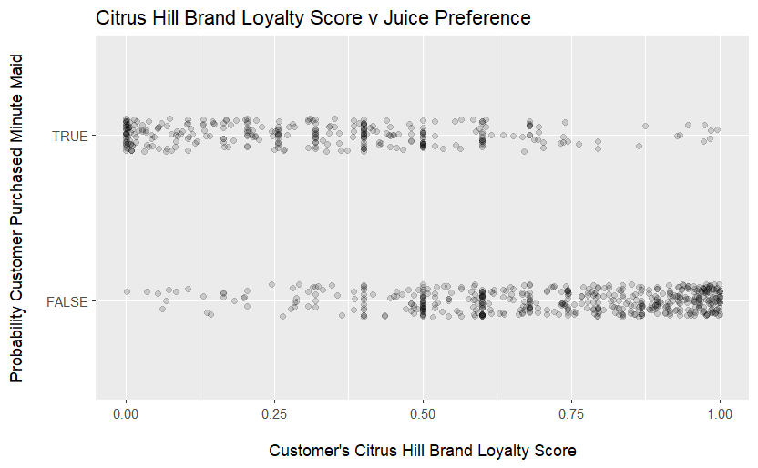

```r
juice_train_trim %>%
  ggplot() +
  aes(x = loyal_ch, y = purchase) +
  geom_jitter(position = position_jitter(h = 0.1), alpha = 0.15) +
  labs(title = "Citrus Hill Brand Loyalty Score v Juice Preference",
       y = "Probability Customer Purchased Minute Maid\n",
       x = "\nCustomer's Citrus Hill Brand Loyalty Score")
```

This plot confirms that customers with higher Citrus Hill brand loyalty scores will usually choose to buy Citrus Hill over Minute Maid.

Applying brand loyalty score `loyal_ch` as a first predictor, the first attempt at creating a model can be started;

#### First Predictor

###### mod1a

```r
juice_1a <- glm(purchase ~ loyal_ch, data = juice_train_trim,
                family = binomial(link = "logit"))

juice_1a
```

```
Call:  glm(formula = purchase ~ loyal_ch, family = binomial(link = "logit"),
    data = juice_train_trim)

Coefficients:
(Intercept)     loyal_ch
      2.801       -6.214

Degrees of Freedom: 855 Total (i.e. Null);  854 Residual
Null Deviance:      1142
Residual Deviance: 722.1    AIC: 726.1
```

Plotting this as a function of `purchase` gives the following;

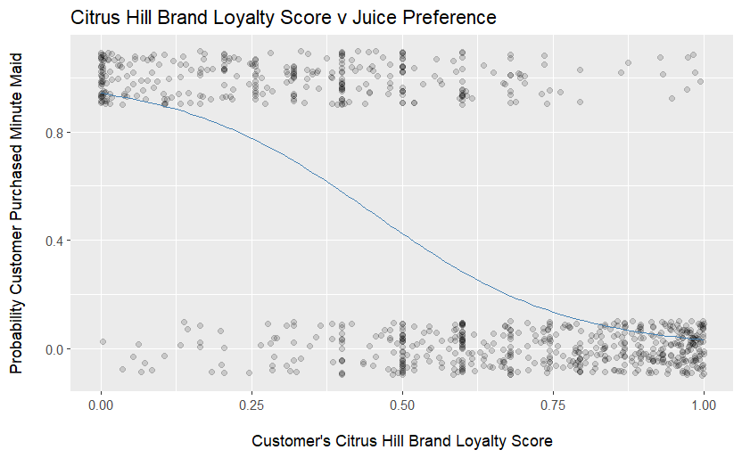

```r
predict_1a <- tibble(loyal_ch = seq(0, 1, 0.01)) %>%
  add_predictions(juice_1a, type = "response")

juice_train_trim %>%
ggplot() +
  aes(x = loyal_ch, y = as.integer(purchase)) +
  geom_jitter(position = position_jitter(h = 0.1), alpha = 0.15) +
  geom_line(data = predict_1a,
            aes(x = loyal_ch, y = pred),
            colour = "steelblue") +
  labs(title = "Citrus Hill Brand Loyalty Score v Juice Preference",
       y = "Probability Customer Purchased Minute Maid\n",
       x = "\nCustomer's Citrus Hill Brand Loyalty Score")
```

```r
NA
NA
```

The calculations above suggest that if a customer’s Citrus Hill brand loyalty score increases by one unit, then the log of the odds of purchasing a Minute Maid decreases by around 6 units.

Check what the train data looks like with predictions;

```r
juice_1a_with_pred <- juice_train_trim %>%
  add_predictions(juice_1a, type = "response")
head(juice_1a_with_pred)
```

| purchase | weekof_purchase | price_ch | price_mm | disc_ch | disc_mm | special_ch | special_mm | loyal_ch | pct_disc_mm | pct_disc_ch | store | pred |
| --- | --- | --- | --- | --- | --- | --- | --- | --- | --- | --- | --- | --- |
| FALSE | 237 | 1.75 | 1.99 | 0.00 | 0.0 | 0 | 0 | 0.500000 | 0.000000 | 0.000000 | 1 | 0.42418223 |
| FALSE | 239 | 1.75 | 1.99 | 0.00 | 0.3 | 0 | 1 | 0.600000 | 0.150754 | 0.000000 | 1 | 0.28352342 |
| FALSE | 245 | 1.86 | 2.09 | 0.17 | 0.0 | 0 | 0 | 0.680000 | 0.000000 | 0.091398 | 1 | 0.19400572 |
| FALSE | 228 | 1.69 | 1.69 | 0.00 | 0.0 | 0 | 0 | 0.956535 | 0.000000 | 0.000000 | 0 | 0.04138225 |
| FALSE | 230 | 1.69 | 1.99 | 0.00 | 0.0 | 0 | 1 | 0.965228 | 0.000000 | 0.000000 | 0 | 0.03929158 |
| FALSE | 232 | 1.69 | 1.99 | 0.00 | 0.4 | 1 | 1 | 0.972182 | 0.201005 | 0.000000 | 0 | 0.03769245 |

```r
summary(juice_1a)
```

```
Call:
glm(formula = purchase ~ loyal_ch, family = binomial(link = "logit"),
    data = juice_train_trim)

Deviance Residuals:
    Min       1Q   Median       3Q      Max
-2.3858  -0.6568  -0.2903   0.5995   2.6134

Coefficients:
            Estimate Std. Error z value Pr(>|z|)
(Intercept)   2.8015     0.2262   12.39   <2e-16 ***
loyal_ch     -6.2142     0.4094  -15.18   <2e-16 ***
---
Signif. codes:  0 ‘***’ 0.001 ‘**’ 0.01 ‘*’ 0.05 ‘.’ 0.1 ‘ ’ 1

(Dispersion parameter for binomial family taken to be 1)

    Null deviance: 1142.32  on 855  degrees of freedom
Residual deviance:  722.08  on 854  degrees of freedom
AIC: 726.08

Number of Fisher Scoring iterations: 5
```

The problem with trying to make predictions at this stage is that there is currently no threshold set to define at what probability a customer would choose Minute Maid over Citrus Hill. Try 0.5;

```r
threshold <- 0.5

juice_1a_with_pred <- juice_1a_with_pred %>%
  mutate(pred_thresh_0.5 = pred >= threshold) %>%
  relocate(pred_thresh_0.5, .after = "purchase")

head(juice_1a_with_pred, 10)
```

| purchase | pred_thresh_0.5 | weekof_purchase | price_ch | price_mm | disc_ch | disc_mm | special_ch | special_mm | loyal_ch | pct_disc_mm | pct_disc_ch | store | pred |
| --- | --- | --- | --- | --- | --- | --- | --- | --- | --- | --- | --- | --- | --- |
| FALSE | FALSE | 237 | 1.75 | 1.99 | 0.00 | 0.00 | 0 | 0 | 0.500000 | 0.000000 | 0.000000 | 1 | 0.42418223 |
| FALSE | FALSE | 239 | 1.75 | 1.99 | 0.00 | 0.30 | 0 | 1 | 0.600000 | 0.150754 | 0.000000 | 1 | 0.28352342 |
| FALSE | FALSE | 245 | 1.86 | 2.09 | 0.17 | 0.00 | 0 | 0 | 0.680000 | 0.000000 | 0.091398 | 1 | 0.19400572 |
| FALSE | FALSE | 228 | 1.69 | 1.69 | 0.00 | 0.00 | 0 | 0 | 0.956535 | 0.000000 | 0.000000 | 0 | 0.04138225 |
| FALSE | FALSE | 230 | 1.69 | 1.99 | 0.00 | 0.00 | 0 | 1 | 0.965228 | 0.000000 | 0.000000 | 0 | 0.03929158 |
| FALSE | FALSE | 232 | 1.69 | 1.99 | 0.00 | 0.40 | 1 | 1 | 0.972182 | 0.201005 | 0.000000 | 0 | 0.03769245 |
| FALSE | FALSE | 234 | 1.75 | 1.99 | 0.00 | 0.40 | 1 | 0 | 0.977746 | 0.201005 | 0.000000 | 0 | 0.03645817 |
| FALSE | FALSE | 235 | 1.75 | 1.99 | 0.00 | 0.40 | 0 | 0 | 0.982197 | 0.201005 | 0.000000 | 0 | 0.03549888 |
| FALSE | FALSE | 238 | 1.75 | 1.99 | 0.00 | 0.40 | 0 | 0 | 0.985757 | 0.201005 | 0.000000 | 0 | 0.03474916 |
| FALSE | FALSE | 276 | 1.99 | 2.13 | 0.00 | 0.54 | 0 | 1 | 0.992708 | 0.253521 | 0.000000 | 0 | 0.03332909 |

The performance of the model can be checked with a confusion table;

```r
conf_table <- juice_1a_with_pred %>%
  tabyl(purchase, pred_thresh_0.5)

conf_table
```

```
 purchase FALSE TRUE
    FALSE   465   60
     TRUE    92  239
```

```r
juice_1a_with_pred %>%
  accuracy(as.factor(purchase), as.factor(pred_thresh_0.5))
```

| .metric | .estimator | .estimate |
| --- | --- | --- |
| accuracy | binary | 0.8224299 |

Does this improve with a higher threshold? Can’t think why it would in this case where we only have a choice between one of two drinks, but try 0.6;

```r
threshold <- 0.6

juice_1a_with_pred <- juice_1a_with_pred %>%
  mutate(pred_thresh_0.6 = pred >= threshold) %>%
  relocate(pred_thresh_0.6, .after = "purchase")

head(juice_1a_with_pred, 10)
```

| purchase | pred_thresh_0.6 | pred_thresh_0.5 | weekof_purchase | price_ch | price_mm | disc_ch | disc_mm | special_ch | special_mm | loyal_ch | pct_disc_mm | pct_disc_ch | store | pred |
| --- | --- | --- | --- | --- | --- | --- | --- | --- | --- | --- | --- | --- | --- | --- |
| FALSE | FALSE | FALSE | 237 | 1.75 | 1.99 | 0.00 | 0.00 | 0 | 0 | 0.500000 | 0.000000 | 0.000000 | 1 | 0.42418223 |
| FALSE | FALSE | FALSE | 239 | 1.75 | 1.99 | 0.00 | 0.30 | 0 | 1 | 0.600000 | 0.150754 | 0.000000 | 1 | 0.28352342 |
| FALSE | FALSE | FALSE | 245 | 1.86 | 2.09 | 0.17 | 0.00 | 0 | 0 | 0.680000 | 0.000000 | 0.091398 | 1 | 0.19400572 |
| FALSE | FALSE | FALSE | 228 | 1.69 | 1.69 | 0.00 | 0.00 | 0 | 0 | 0.956535 | 0.000000 | 0.000000 | 0 | 0.04138225 |
| FALSE | FALSE | FALSE | 230 | 1.69 | 1.99 | 0.00 | 0.00 | 0 | 1 | 0.965228 | 0.000000 | 0.000000 | 0 | 0.03929158 |
| FALSE | FALSE | FALSE | 232 | 1.69 | 1.99 | 0.00 | 0.40 | 1 | 1 | 0.972182 | 0.201005 | 0.000000 | 0 | 0.03769245 |
| FALSE | FALSE | FALSE | 234 | 1.75 | 1.99 | 0.00 | 0.40 | 1 | 0 | 0.977746 | 0.201005 | 0.000000 | 0 | 0.03645817 |
| FALSE | FALSE | FALSE | 235 | 1.75 | 1.99 | 0.00 | 0.40 | 0 | 0 | 0.982197 | 0.201005 | 0.000000 | 0 | 0.03549888 |
| FALSE | FALSE | FALSE | 238 | 1.75 | 1.99 | 0.00 | 0.40 | 0 | 0 | 0.985757 | 0.201005 | 0.000000 | 0 | 0.03474916 |
| FALSE | FALSE | FALSE | 276 | 1.99 | 2.13 | 0.00 | 0.54 | 0 | 1 | 0.992708 | 0.253521 | 0.000000 | 0 | 0.03332909 |

The performance of the model can be checked with a confusion table;

```r
conf_table <- juice_1a_with_pred %>%
  tabyl(purchase, pred_thresh_0.6)

conf_table
```

```
 purchase FALSE TRUE
    FALSE   482   43
     TRUE   134  197
```

```r
juice_1a_with_pred %>%
  accuracy(as.factor(purchase), as.factor(pred_thresh_0.6))
```

| .metric | .estimator | .estimate |
| --- | --- | --- |
| accuracy | binary | 0.7932243 |

Reset threshold back to 0.5;

```r
threshold <- 0.5
```

#### Second Predictor

###### mod2a

```r
juice_second <- glm(purchase ~ ., data = juice_train_trim,
                family = binomial(link = "logit"))

summary(juice_second)
```

```
Call:
glm(formula = purchase ~ ., family = binomial(link = "logit"),
    data = juice_train_trim)

Deviance Residuals:
    Min       1Q   Median       3Q      Max
-2.7684  -0.5396  -0.2403   0.5149   2.7944

Coefficients:
                  Estimate Std. Error z value Pr(>|z|)
(Intercept)       7.153688   2.315460   3.090  0.00200 **
weekof_purchase   0.008118   0.011547   0.703  0.48203
price_ch          0.702781   1.891581   0.372  0.71024
price_mm         -3.824871   1.024875  -3.732  0.00019 ***
disc_ch           5.669016  21.411001   0.265  0.79119
disc_mm          27.148662  10.241335   2.651  0.00803 **
special_ch        0.178464   0.385657   0.463  0.64354
special_mm        0.089835   0.305162   0.294  0.76846
loyal_ch         -6.546769   0.446610 -14.659  < 2e-16 ***
pct_disc_mm     -51.747992  21.437494  -2.414  0.01578 *
pct_disc_ch     -18.733161  40.189186  -0.466  0.64113
store             0.143843   0.094826   1.517  0.12929
---
Signif. codes:  0 ‘***’ 0.001 ‘**’ 0.01 ‘*’ 0.05 ‘.’ 0.1 ‘ ’ 1

(Dispersion parameter for binomial family taken to be 1)

    Null deviance: 1142.32  on 855  degrees of freedom
Residual deviance:  649.37  on 844  degrees of freedom
AIC: 673.37

Number of Fisher Scoring iterations: 5
```

It looks like `price_mm` is a likely candidate for the next predictor;

*I misread the summary table first time round and took `price_ch` by mistake -* *it wasn’t until I looked at my results that I realised my error! Have left the* *code in but commented it out…*

```r
# juice_2a <- glm(purchase ~ loyal_ch + price_ch, data = juice_train_trim,
#                 family = binomial(link = "logit"))
#
# juice_2a
```

```r
# tidy_out <- tidy(juice_2a)
# tidy_out
```

###### mod2b

It would seem sensible that if a lower price was offered on Minute Maid then the probability might go up that more people would choose this drink.

```r
juice_2b <- glm(purchase ~ loyal_ch + price_mm, data = juice_train_trim,
                family = binomial(link = "logit"))

summary(juice_2b)
```

```
Call:
glm(formula = purchase ~ loyal_ch + price_mm, family = binomial(link = "logit"),
    data = juice_train_trim)

Deviance Residuals:
    Min       1Q   Median       3Q      Max
-2.4928  -0.6187  -0.2890   0.5738   2.6532

Coefficients:
            Estimate Std. Error z value Pr(>|z|)
(Intercept)   6.7586     1.4061   4.807 1.54e-06 ***
loyal_ch     -6.1471     0.4085 -15.047  < 2e-16 ***
price_mm     -1.9222     0.6677  -2.879  0.00399 **
---
Signif. codes:  0 ‘***’ 0.001 ‘**’ 0.01 ‘*’ 0.05 ‘.’ 0.1 ‘ ’ 1

(Dispersion parameter for binomial family taken to be 1)

    Null deviance: 1142.32  on 855  degrees of freedom
Residual deviance:  713.57  on 853  degrees of freedom
AIC: 719.57

Number of Fisher Scoring iterations: 5
```

Including `price_mm` returns an AIC marginally lower than `loyal_ch` on it’s own, suggesting it might create a better fitting model.

```r
tidy_out <- tidy(juice_2b)
tidy_out
```

| term | estimate | std.error | statistic | p.value |
| --- | --- | --- | --- | --- |
| (Intercept) | 6.758609 | 1.4061155 | 4.806582 | 1.535327e-06 |
| loyal_ch | -6.147065 | 0.4085278 | -15.046869 | 3.619633e-51 |
| price_mm | -1.922203 | 0.6677356 | -2.878688 | 3.993332e-03 |

So the model so far is;

$$purchase \sim loyal\_ch + price\_mm$$

```r
juice_2b_with_pred <- juice_train_trim %>%
  add_predictions(juice_2b, type = "response")
head(juice_2b_with_pred)
```

| purchase | weekof_purchase | price_ch | price_mm | disc_ch | disc_mm | special_ch | special_mm | loyal_ch | pct_disc_mm | pct_disc_ch | store | pred |
| --- | --- | --- | --- | --- | --- | --- | --- | --- | --- | --- | --- | --- |
| FALSE | 237 | 1.75 | 1.99 | 0.00 | 0.0 | 0 | 0 | 0.500000 | 0.000000 | 0.000000 | 1 | 0.46503061 |
| FALSE | 239 | 1.75 | 1.99 | 0.00 | 0.3 | 0 | 1 | 0.600000 | 0.150754 | 0.000000 | 1 | 0.31977353 |
| FALSE | 245 | 1.86 | 2.09 | 0.17 | 0.0 | 0 | 0 | 0.680000 | 0.000000 | 0.091398 | 1 | 0.19173153 |
| FALSE | 228 | 1.69 | 1.69 | 0.00 | 0.0 | 0 | 0 | 0.956535 | 0.000000 | 0.000000 | 0 | 0.08550511 |
| FALSE | 230 | 1.69 | 1.99 | 0.00 | 0.0 | 0 | 1 | 0.965228 | 0.000000 | 0.000000 | 0 | 0.04743071 |
| FALSE | 232 | 1.69 | 1.99 | 0.00 | 0.4 | 1 | 1 | 0.972182 | 0.201005 | 0.000000 | 0 | 0.04553631 |

```r
summary(juice_2b)
```

```
Call:
glm(formula = purchase ~ loyal_ch + price_mm, family = binomial(link = "logit"),
    data = juice_train_trim)

Deviance Residuals:
    Min       1Q   Median       3Q      Max
-2.4928  -0.6187  -0.2890   0.5738   2.6532

Coefficients:
            Estimate Std. Error z value Pr(>|z|)
(Intercept)   6.7586     1.4061   4.807 1.54e-06 ***
loyal_ch     -6.1471     0.4085 -15.047  < 2e-16 ***
price_mm     -1.9222     0.6677  -2.879  0.00399 **
---
Signif. codes:  0 ‘***’ 0.001 ‘**’ 0.01 ‘*’ 0.05 ‘.’ 0.1 ‘ ’ 1

(Dispersion parameter for binomial family taken to be 1)

    Null deviance: 1142.32  on 855  degrees of freedom
Residual deviance:  713.57  on 853  degrees of freedom
AIC: 719.57

Number of Fisher Scoring iterations: 5
```

So both `loyal_ch` and `price_mm` are significant and the AIC with two predictors is slightly smaller than with one predictor.

Check predictions again against threshold = 0.5;

```r
threshold <- 0.5

juice_2b_with_pred <- juice_2b_with_pred %>%
  mutate(pred_thresh_0.5 = pred >= threshold) %>%
  relocate(pred_thresh_0.5, .after = "purchase")

head(juice_2b_with_pred, 10)
```

| purchase | pred_thresh_0.5 | weekof_purchase | price_ch | price_mm | disc_ch | disc_mm | special_ch | special_mm | loyal_ch | pct_disc_mm | pct_disc_ch | store | pred |
| --- | --- | --- | --- | --- | --- | --- | --- | --- | --- | --- | --- | --- | --- |
| FALSE | FALSE | 237 | 1.75 | 1.99 | 0.00 | 0.00 | 0 | 0 | 0.500000 | 0.000000 | 0.000000 | 1 | 0.46503061 |
| FALSE | FALSE | 239 | 1.75 | 1.99 | 0.00 | 0.30 | 0 | 1 | 0.600000 | 0.150754 | 0.000000 | 1 | 0.31977353 |
| FALSE | FALSE | 245 | 1.86 | 2.09 | 0.17 | 0.00 | 0 | 0 | 0.680000 | 0.000000 | 0.091398 | 1 | 0.19173153 |
| FALSE | FALSE | 228 | 1.69 | 1.69 | 0.00 | 0.00 | 0 | 0 | 0.956535 | 0.000000 | 0.000000 | 0 | 0.08550511 |
| FALSE | FALSE | 230 | 1.69 | 1.99 | 0.00 | 0.00 | 0 | 1 | 0.965228 | 0.000000 | 0.000000 | 0 | 0.04743071 |
| FALSE | FALSE | 232 | 1.69 | 1.99 | 0.00 | 0.40 | 1 | 1 | 0.972182 | 0.201005 | 0.000000 | 0 | 0.04553631 |
| FALSE | FALSE | 234 | 1.75 | 1.99 | 0.00 | 0.40 | 1 | 0 | 0.977746 | 0.201005 | 0.000000 | 0 | 0.04407268 |
| FALSE | FALSE | 235 | 1.75 | 1.99 | 0.00 | 0.40 | 0 | 0 | 0.982197 | 0.201005 | 0.000000 | 0 | 0.04293424 |
| FALSE | FALSE | 238 | 1.75 | 1.99 | 0.00 | 0.40 | 0 | 0 | 0.985757 | 0.201005 | 0.000000 | 0 | 0.04204397 |
| FALSE | FALSE | 276 | 1.99 | 2.13 | 0.00 | 0.54 | 0 | 1 | 0.992708 | 0.253521 | 0.000000 | 0 | 0.03113108 |

The performance of the model can be checked with a confusion table;

```r
conf_table <- juice_2b_with_pred %>%
  tabyl(purchase, pred_thresh_0.5)

conf_table
```

```
 purchase FALSE TRUE
    FALSE   460   65
     TRUE    91  240
```

```r
juice_2b_with_pred %>%
  accuracy(as.factor(purchase), as.factor(pred_thresh_0.5))
```

| .metric | .estimator | .estimate |
| --- | --- | --- |
| accuracy | binary | 0.817757 |

Again, an accuracy of 80%. The sensitivity (or True Positive Rate) is;

```r
juice_2b_with_pred %>%
  sensitivity(as.factor(purchase), as.factor(pred_thresh_0.5))
```

| .metric | .estimator | .estimate |
| --- | --- | --- |
| sensitivity | binary | 0.8761905 |

And the specificity (True Negative Rate);

```r
juice_2b_with_pred %>%
  specificity(as.factor(purchase), as.factor(pred_thresh_0.5))
```

| .metric | .estimator | .estimate |
| --- | --- | --- |
| specificity | binary | 0.7250755 |

The True Negative Rate is around 70%, which is a little worse than the TPR.

### Check Model Performance

#### ROC Curve

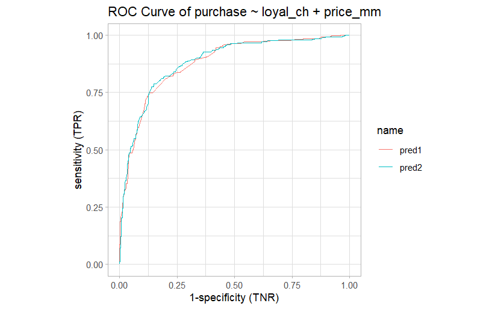

```r
roc_obj_1pred <- juice_1a_with_pred %>%
  roc(response = purchase, predictor = pred)
roc_obj_2pred <- juice_2b_with_pred %>%
  roc(response = purchase, predictor = pred)
roc_curve <- ggroc(data = list(pred1 = roc_obj_1pred,
                               pred2 = roc_obj_2pred),
                   legacy.axes = TRUE) +
  coord_fixed() +
  labs(title = "ROC Curve of purchase ~ loyal_ch + price_mm",
       x = "1-specificity (TNR)",
       y = "sensitivity (TPR)") +
  theme_light()

roc_curve
```

The ROC curve suggests that the 2-predictor model is very marginally better than the single predictor model (i.e. it is closer to the top left corner).

#### AUC

```r
auc(roc_obj_1pred)
```

```
Area under the curve: 0.879
```

```r
auc(roc_obj_2pred)
```

```
Area under the curve: 0.8825
```

The AUC also backs up the first impressions of the two-predictor model being a better fit to the training data.

#### Gini Coefficient

The Gini coefficient normalises AUC so that a random classifier has value 0, and a perfect classifier has value 1.

Gini = 2 × AUC − 1

with a possible range of values

−1 ≤ Gini ≤ 1

Although, as for AUC, the practical range is

0 ≤ Gini ≤ 1

```r
gini_1pred <-  2 * auc(roc_obj_1pred) - 1
gini_1pred
```

```
[1] 0.7579974
```

```r
gini_2pred <-  2 * auc(roc_obj_2pred) - 1
gini_2pred
```

```
[1] 0.765041
```

The Gini coefficient also backs the theory that the two predictor model is a better fit to the training data.

#### Add in the Test Data Set

1. Tidy up the data;

```r
juice_test_trim <- juice_test %>%
  mutate(purchase = if_else(purchase == "MM", as.logical(TRUE), as.logical(FALSE))) %>%
  select(-c(sale_price_mm,
            sale_price_ch,
            price_diff,
            list_price_diff,
            store_id,
            store7))
```

2. Apply the model;

```r
juice_model <- glm(purchase ~ loyal_ch + price_mm, data = juice_test_trim,
                family = binomial(link = "logit"))

juice_model
```

```
Call:  glm(formula = purchase ~ loyal_ch + price_mm, family = binomial(link = "logit"),
    data = juice_test_trim)

Coefficients:
(Intercept)     loyal_ch     price_mm
     4.1854      -5.5995      -0.7895

Degrees of Freedom: 213 Total (i.e. Null);  211 Residual
Null Deviance:      288.4
Residual Deviance: 197.5    AIC: 203.5
```

3. Add Predictions;

```r
juice_test_with_pred <- juice_test_trim %>%
  add_predictions(juice_2b, type = "response")
head(juice_test_with_pred)
```

| purchase | weekof_purchase | price_ch | price_mm | disc_ch | disc_mm | special_ch | special_mm | loyal_ch | pct_disc_mm | pct_disc_ch | store | pred |
| --- | --- | --- | --- | --- | --- | --- | --- | --- | --- | --- | --- | --- |
| FALSE | 270 | 1.86 | 2.18 | 0 | 0 | 0 | 0 | 0.339223 | 0 | 0 | 2 | 0.6184517 |
| TRUE | 256 | 1.99 | 2.29 | 0 | 0 | 0 | 0 | 0.320000 | 0 | 0 | 3 | 0.5962116 |
| FALSE | 228 | 1.69 | 1.69 | 0 | 0 | 0 | 0 | 0.480000 | 0 | 0 | 2 | 0.6363359 |
| TRUE | 235 | 1.79 | 2.09 | 0 | 0 | 0 | 0 | 0.131072 | 0 | 0 | 3 | 0.8738567 |
| FALSE | 234 | 1.79 | 2.09 | 0 | 0 | 0 | 0 | 0.299008 | 0 | 0 | 3 | 0.7116034 |
| FALSE | 236 | 1.79 | 2.09 | 0 | 0 | 0 | 0 | 0.600000 | 0 | 0 | 3 | 0.2794819 |

4. Check predictions again against threshold = 0.5;

```r
threshold <- 0.5

juice_test_with_pred <- juice_test_with_pred %>%
  mutate(pred_thresh_0.5 = pred >= threshold) %>%
  relocate(pred_thresh_0.5, .after = "purchase")

head(juice_test_with_pred, 10)
```

| purchase | pred_thresh_0.5 | weekof_purchase | price_ch | price_mm | disc_ch | disc_mm | special_ch | special_mm | loyal_ch | pct_disc_mm | pct_disc_ch | store | pred |
| --- | --- | --- | --- | --- | --- | --- | --- | --- | --- | --- | --- | --- | --- |
| FALSE | TRUE | 270 | 1.86 | 2.18 | 0.00 | 0 | 0 | 0 | 0.339223 | 0 | 0.000000 | 2 | 0.6184517 |
| TRUE | TRUE | 256 | 1.99 | 2.29 | 0.00 | 0 | 0 | 0 | 0.320000 | 0 | 0.000000 | 3 | 0.5962116 |
| FALSE | TRUE | 228 | 1.69 | 1.69 | 0.00 | 0 | 0 | 0 | 0.480000 | 0 | 0.000000 | 2 | 0.6363359 |
| TRUE | TRUE | 235 | 1.79 | 2.09 | 0.00 | 0 | 0 | 0 | 0.131072 | 0 | 0.000000 | 3 | 0.8738567 |
| FALSE | TRUE | 234 | 1.79 | 2.09 | 0.00 | 0 | 0 | 0 | 0.299008 | 0 | 0.000000 | 3 | 0.7116034 |
| FALSE | FALSE | 236 | 1.79 | 2.09 | 0.00 | 0 | 0 | 0 | 0.600000 | 0 | 0.000000 | 3 | 0.2794819 |
| FALSE | FALSE | 231 | 1.79 | 1.79 | 0.00 | 0 | 0 | 0 | 0.833801 | 0 | 0.000000 | 4 | 0.1409330 |
| TRUE | FALSE | 228 | 1.69 | 1.69 | 0.00 | 0 | 0 | 0 | 0.744000 | 0 | 0.000000 | 0 | 0.2566737 |
| FALSE | TRUE | 253 | 1.86 | 2.09 | 0.10 | 0 | 0 | 0 | 0.400000 | 0 | 0.053763 | 0 | 0.5701296 |
| TRUE | TRUE | 256 | 1.89 | 2.18 | 0.13 | 0 | 0 | 0 | 0.022751 | 0 | 0.068783 | 2 | 0.9189642 |

5. Check Accuracy / Specificity / Sensitivity The performance of the model can be checked with a confusion table;

```r
conf_table <- juice_test_with_pred %>%
  tabyl(purchase, pred_thresh_0.5)

conf_table
```

```
 purchase FALSE TRUE
    FALSE   106   22
     TRUE    30   56
```

```r
juice_test_with_pred %>%
  accuracy(as.factor(purchase), as.factor(pred_thresh_0.5))
```

| .metric | .estimator | .estimate |
| --- | --- | --- |
| accuracy | binary | 0.7570093 |

```r
juice_test_with_pred %>%
  sensitivity(as.factor(purchase), as.factor(pred_thresh_0.5))
```

| .metric | .estimator | .estimate |
| --- | --- | --- |
| sensitivity | binary | 0.828125 |

The True Positive Rate is 83%, which seems quite good.

And the specificity (True Negative Rate);

```r
juice_test_with_pred %>%
  specificity(as.factor(purchase), as.factor(pred_thresh_0.5))
```

| .metric | .estimator | .estimate |
| --- | --- | --- |
| specificity | binary | 0.6511628 |

#### Summary

$$purchase_{(MM\ or\ CH)} \sim CH\_brand\_loyalty + price\_MM$$